# Examining the Role of Outness on Self-Reported Health Among LGBTQ+ People

Kaylee Foor

# Background

Since its conception in 2003, the Minority Stress Model has been a cornerstone of minority health research (Meyer, 2003). This framework theorizes a mechanism by which people who identify with minoritized groups (e.g., LGBTQ+ people, non-White racial groups, etc.) experience health disparities due to exposure to identity-specific stressors in addition to everyday ones. This model is widely known and nearly exclusively cited in minority health research. While the importance of this work cannot be denied, prioritizing this framework above all others limits the new and interesting information we can glean about the experiences of marginalized populations. In particular, taking such a deficit-focused approach mitigates our ability to ask detailed questions about resilience and thriving. This is particularly true for research on LGBTQ+ experiences, as the majority of work in this space is deficit-focused. To address this, the present analysis explores how resilience factors (e.g., outness, relationship quality, etc.) contribute to more positive health outcomes for LGBTQ+ people.

I draw from the National Couples Health and Time Survey (NCHATS) dataset to ask these questions. This is a population-based survey study that was implemented in 2020 and 2021. The primary study asks questions related to COVID-19, contributors to health, and relationship dynamics among 3642 participants. All participants were married or cohabitating at the time of responding, aged 20-60, and diverse in sexual orientation (55% straight/heterosexual, 20% gay/lesbian, 10% bisexual, 15% other). For the purposes of this present investigation, only participants who do not identify as straight/heterosexual are considered in analyses (n=1516).

# Variables

*Demographics*

- **sexual_orientation** (factor): collapsed into categories of interest (homosexual, bisexual/pansexual, other) from indicator variables reported by participants (original options: heterosexual, homosexual, bisexual, same gender loving, queer, pansexual, omnisexual, asexual, questionning, don’t know, something else)
- **participant_gender** (factor): reported by participants (options: man, woman, transgender, other)
- **partner_gender** (factor): reported by participants with the same choice options as participant_gender
- **age** (numeric): participant age (in years) at time of survey

*Resilience*

- **support_total** (numeric): total extent of reliance on partner (ss_partner), family (ss_family), and friends (ss_friends). Participants responded to each individual item on a 5-point likert-scale (1=“Not at all” and 5=“A great deal). Total (summed) score may range from 3 to 15.
- **outness_total** (numeric): total extent of outness to family (out_family), friends (out_friends), coworkers (out_coworkers), and healthcare professionals (out_hp). Participants responded to each individual item on a 4-point likert scale (1=all, 4=none – reverse-scored for analysis)
- **identity_centrality** (numeric): single-item likert-type question to assess how central participants’ sexual orientation is to their identity (1=“strongly disagree”, 5=“strongly agree”)

*Relationship Quality*

- **csi** (numeric): total score for 4-item Couples’ Satisfaction Index (1=“not at all”, 7=“perfect” for each of the four scale items). `csi` represents the total sum score for these items.

*Health*

- **health_self** (numeric): single-item likert-type question to assess participant perception of their overall health (1=“poor” and 5=“excellent”)

*Covariates*

- **stress** (numeric): single-item likert-type question to assess how stressed the participant was over the past week (1=“not at all stressed” and 5=“very stressed”)

# Hypotheses

I predict that outness will be positively associated with health, such that people who are more “out” about their queer identity will report better health outcomes. I predict that relationship quality–operationalized as couples’ satisfaction–will mediate this relationship. I predict that stress will moderate this relationship, such that people with lower stress will exhibit a more positive relationship between outness and health compared to those with higher stress levels.

# Data Organization

```r
#Create new dataframe with only LGBTQ+ participants
df1 <- subset(nchat_mediation_data, heterosexual == 0)
```

### Data Cleansing and Tidying

```r
#Transform categorical variables to factor
cat_vars <- c("heterosexual", "homosexual", "bisexual", "same_gender_loving",
              "queer", "pansexual", "omnisexual", "asexual",
              "dont_know", "questioning", "something_else", "participant_gender",
              "partner_gender")
df1[,cat_vars] <- lapply(df1[,cat_vars], as.factor)
```

```r
#Identify and impute values for missing observations
sapply(df1,function(x) sum(is.na(x)))
```

```
##         heterosexual           homosexual             bisexual
##                    0                    0                    0
##   same_gender_loving                queer            pansexual
##                    0                    0                    0
##           omnisexual              asexual            dont_know
##                    0                    0                    0
##          questioning       something_else   participant_gender
##                    0                    0                    2
##       partner_gender     community_safety           ss_partner
##                    0                    1                    0
##            ss_family           ss_friends           out_family
##                    0                    1                    6
##          out_friends        out_coworkers               out_hp
##                    5                  256                    4
##  identity_centrality       legal_marriage  commitment_ceremony
##                    5                    2                    2
## domestic_partnership          civil_union        no_commitment
##                    2                    2                    2
##                csi_1                csi_2                csi_3
##                    1                    4                    0
##                csi_4             freq_arg    partner_support_1
##                    0                    1                    2
##    partner_support_2    partner_support_3    partner_support_4
##                    2                    3                    2
##          health_self       health_partner               stress
##                    4                    2                    9
##                  age           birth_year           race_white
##                   14                   14                   11
##           race_black      race_indigenous    race_asian_indian
##                   11                   11                   11
##        social_status            education
##                    1                    3
```

```r
df <- df1
impute_data <- function(data) {
  missing_cols <- names(data)[sapply(data, function(col) any(is.na(col)))]
  for (col in missing_cols) {
    if (is.numeric(data[[col]])) {
      data[[col]][is.na(data[[col]])] <- mean(data[[col]], na.rm = TRUE)
    } else if (is.factor(data[[col]]) || is.character(data[[col]])) {
      mode_value <- names(sort(table(data[[col]]), decreasing = TRUE))[1] # Find mode
      data[[col]][is.na(data[[col]])] <- mode_value
    }
  }
  return(data)
}
df <- impute_data(df)
sapply(df,function(x) sum(is.na(x)))
```

```
##         heterosexual           homosexual             bisexual
##                    0                    0                    0
##   same_gender_loving                queer            pansexual
##                    0                    0                    0
##           omnisexual              asexual            dont_know
##                    0                    0                    0
##          questioning       something_else   participant_gender
##                    0                    0                    0
##       partner_gender     community_safety           ss_partner
##                    0                    0                    0
##            ss_family           ss_friends           out_family
##                    0                    0                    0
##          out_friends        out_coworkers               out_hp
##                    0                    0                    0
##  identity_centrality       legal_marriage  commitment_ceremony
##                    0                    0                    0
## domestic_partnership          civil_union        no_commitment
##                    0                    0                    0
##                csi_1                csi_2                csi_3
##                    0                    0                    0
##                csi_4             freq_arg    partner_support_1
##                    0                    0                    0
##    partner_support_2    partner_support_3    partner_support_4
##                    0                    0                    0
##          health_self       health_partner               stress
##                    0                    0                    0
##                  age           birth_year           race_white
##                    0                    0                    0
##           race_black      race_indigenous    race_asian_indian
##                    0                    0                    0
##        social_status            education
##                    0                    0
```

```r
#Create Couples Satisfaction Index Variable
csi_vars <- c("csi_1", "csi_2", "csi_3", "csi_4")
df$csi = rowSums(df[,c(csi_vars)], dims=1)
```

```r
#Collapse sexual orientation variable
df$sexual_orientation <- as.factor(ifelse(df$homosexual==1, "homosexual",
                         ifelse(df$bisexual==1, "bisexual/pansexual",
                         ifelse(df$pansexual==1, "bisexual/pansexual",
                         ifelse(df$queer==1, "queer",
                         ifelse(df$same_gender_loving==1 |
                                df$omnisexual==1 |
                                df$asexual==1 |
                                df$dont_know==1 |
                                df$questioning==1 |
                                df$something_else==1, "other", NA))))))
```

```r
#Create binary gender identity of couples variable
df$same_gender_couple <- as.factor(ifelse(df$participant_gender == df$partner_gender,
                                "Yes", "No"))
```

```r
#reverse score outness variables (1=all, 4=none)
df$out_family = 5 - df$out_family
df$out_friends = 5 - df$out_friends
df$out_coworkers = 5 - df$out_coworkers
df$out_hp = 5 - df$out_hp

#Create outness variable
outness_vars <- c("out_family", "out_friends", "out_coworkers", "out_hp")
df$outness_total = rowSums(df[,c(outness_vars)], dims=1)
```

```r
#Create social support variable
support_vars <- c("ss_partner", "ss_family", "ss_friends")
df$support_total <- rowSums(df[,support_vars], dims=1)
```

```r
#Calculate descriptive statistics
cont_vars <- subset(df[,c("community_safety", "support_total", "outness_total",
                          "identity_centrality", "csi", "health_self",
                          "stress", "age")])
cont_names <- c("Community Safety", "Social Support", "Outness",
                     "Identity Centrality", "CSI", "Perceived Health of Self",
                     "Stress", "Age")
cont_vars_df <- as.data.frame(cont_vars)
descriptives <- describe(cont_vars_df, fast=TRUE)
View(descriptives)
```

```r
#Transform continuous vars with skewness >= |1|
df$ss_partner_sq <- (df$ss_partner)^2
df$outness_total_sq <- (df$outness_total)^2
df$csi_sq <- (df$csi)^2
```

### Tidy-Compliant Data Table (Data Architecture)

```r
head(df)
```

| heterosexual | homosexual | bisexual | same_gender_loving | queer | pansexual | omnisexual | asexual | dont_know | questioning | something_else | participant_gender | partner_gender | community_safety | ss_partner | ss_family | ss_friends | out_family | out_friends | out_coworkers | out_hp | identity_centrality | legal_marriage | commitment_ceremony | domestic_partnership | civil_union | no_commitment | csi_1 | csi_2 | csi_3 | … |
| --- | --- | --- | --- | --- | --- | --- | --- | --- | --- | --- | --- | --- | --- | --- | --- | --- | --- | --- | --- | --- | --- | --- | --- | --- | --- | --- | --- | --- | --- | --- |
| 0 | 1 | 0 | 0 | 0 | 0 | 0 | 0 | 0 | 0 | 0 | Woman | Woman | 1 | 2 | 1 | 5 | 3 | 4 | 4.000000 | 4 | 5 | 1 | 0 | 0 | 0 | 0 | 4.776238 | 3 | 3 | … |
| 0 | 0 | 1 | 0 | 0 | 0 | 0 | 0 | 0 | 0 | 0 | Woman | Man | 4 | 5 | 4 | 2 | 2 | 4 | 2.953175 | 4 | 1 | 0 | 0 | 0 | 0 | 1 | 2.000000 | 6 | 4 | … |
| 0 | 1 | 0 | 0 | 0 | 0 | 0 | 0 | 0 | 0 | 0 | Man | Man | 5 | 5 | 5 | 5 | 4 | 4 | 4.000000 | 4 | 5 | 1 | 0 | 0 | 0 | 0 | 4.000000 | 6 | 5 | … |
| 0 | 0 | 1 | 0 | 0 | 0 | 0 | 0 | 0 | 0 | 0 | Woman | Man | 5 | 5 | 2 | 3 | 2 | 2 | 2.953175 | 3 | 5 | 0 | 0 | 0 | 0 | 1 | 6.000000 | 6 | 6 | … |
| 0 | 0 | 1 | 0 | 1 | 0 | 0 | 0 | 0 | 0 | 0 | Woman | Man | 4 | 4 | 4 | 3 | 1 | 2 | 1.000000 | 2 | 3 | 1 | 0 | 0 | 0 | 0 | 6.000000 | 6 | 4 | … |
| 0 | 1 | 0 | 0 | 0 | 0 | 0 | 0 | 0 | 0 | 0 | Man | Man | 3 | 4 | 3 | 4 | 2 | 4 | 4.000000 | 4 | 4 | 1 | 0 | 1 | 0 | 0 | 5.000000 | 5 | 6 | … |

# Analysis

1. Ordinary Least Squares Regression
2. Regression with Multiple Predictors
3. Mediation Analysis

### Ordinary Least Squares Regression

```r
#Create dataset with only predictors and outcome of interest
reg_df <- df %>% select(health_self, outness_total_sq, csi_sq, support_total,
                        participant_gender, same_gender_couple, identity_centrality,
                        age, stress) %>% filter(participant_gender==c("Man", "Woman")) %>% droplevels(df$participant_gender)
reg_df$subject <- seq.int(nrow(reg_df))
```

```r
#Main Effect of Outness on Self-Reported Health
outness.health.reg <- lm(health_self ~ outness_total_sq, data=reg_df)
summary(outness.health.reg)
```

```
##
## Call:
## lm(formula = health_self ~ outness_total_sq, data = reg_df)
##
## Residuals:
##     Min      1Q  Median      3Q     Max
## -2.4705 -0.4706 -0.1376  0.5911  1.9690
##
## Coefficients:
##                   Estimate Std. Error t value Pr(>|t|)
## (Intercept)      2.9834427  0.0861102  34.647  < 2e-16 ***
## outness_total_sq 0.0019028  0.0004348   4.376 1.39e-05 ***
## ---
## Signif. codes:  0 '***' 0.001 '**' 0.01 '*' 0.05 '.' 0.1 ' ' 1
##
## Residual standard error: 0.9148 on 711 degrees of freedom
## Multiple R-squared:  0.02623,    Adjusted R-squared:  0.02486
## F-statistic: 19.15 on 1 and 711 DF,  p-value: 1.389e-05
```

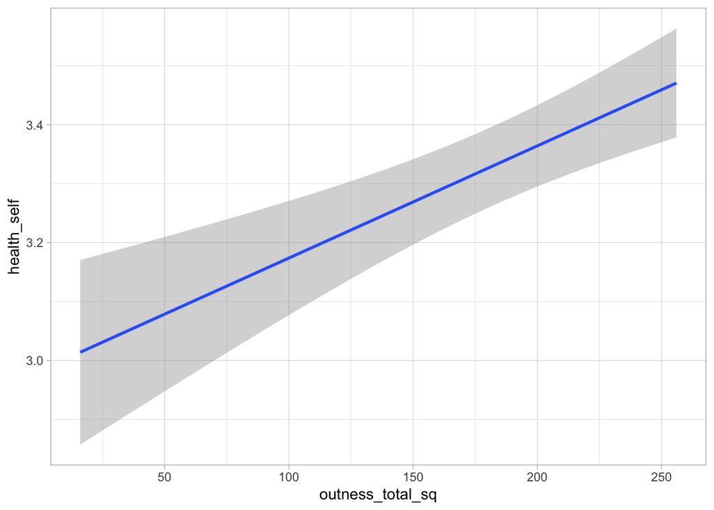

```r
reg_df %>% ggplot(aes(x=outness_total_sq, y=health_self)) + geom_smooth(method="lm") +
  theme_light()
```

Given this model, it appears that outness predicts health, such that people who are more “out” report better health. However, we should check assumptions.

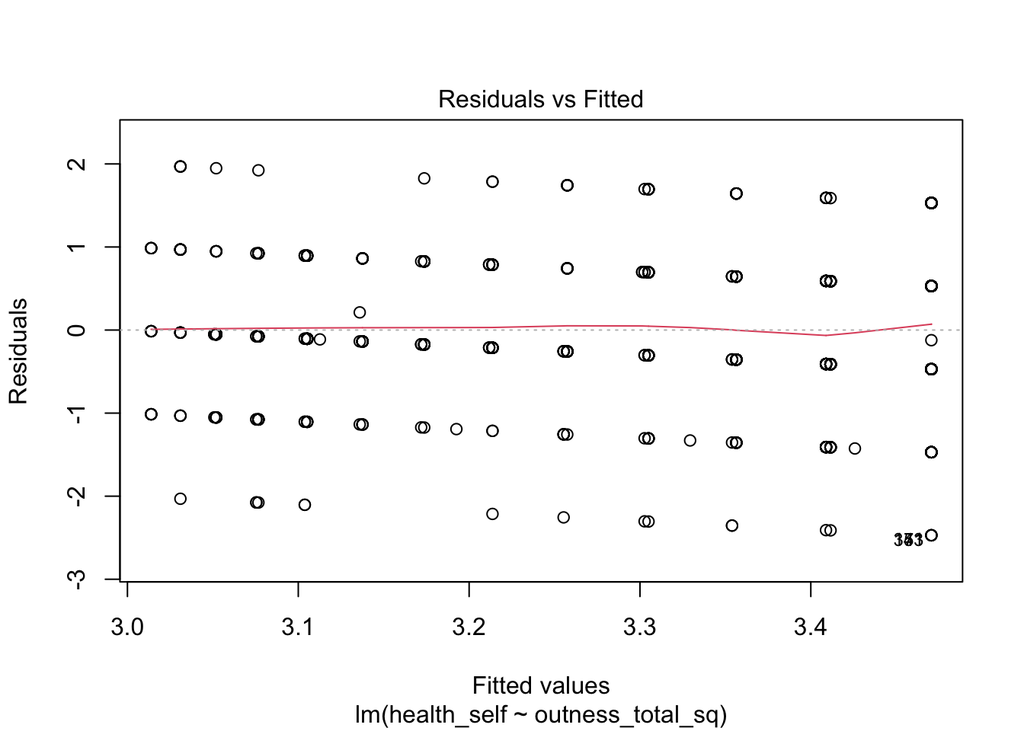

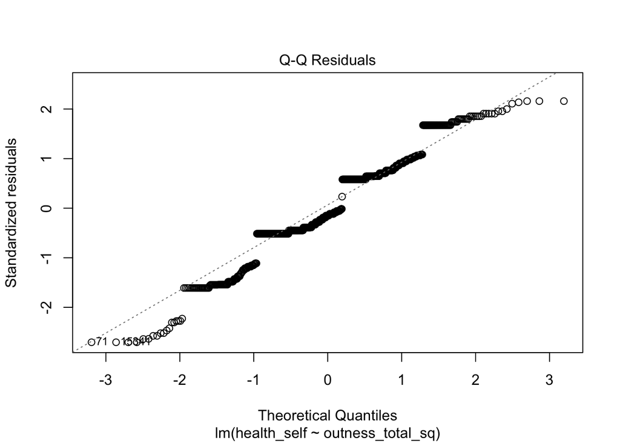

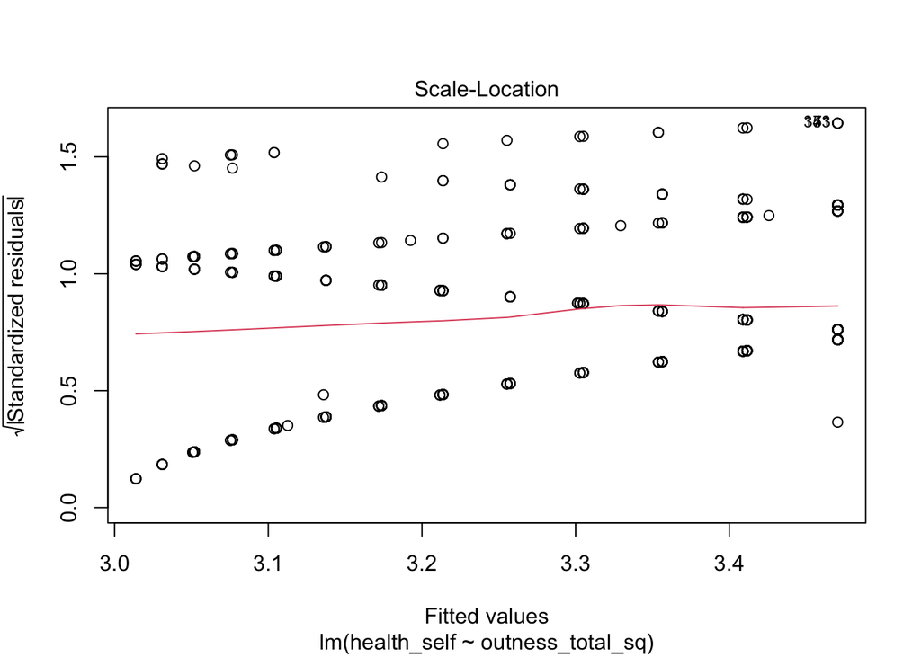

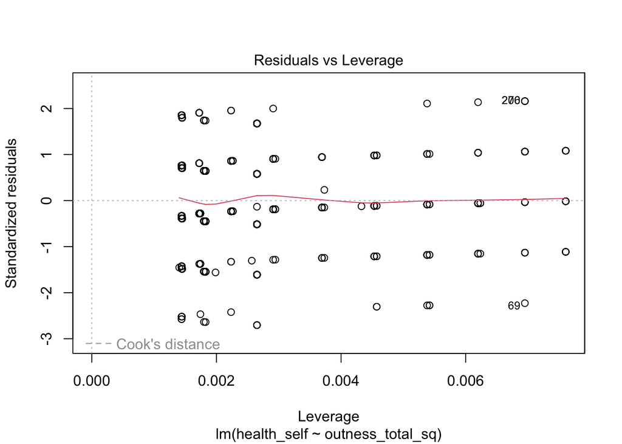

```r
#Create plots to check assumptions of linear regression
plot(outness.health.reg)
```

The residuals-versus-fitted plot suggests that there are no issues with linearity in our model, as the red line is approximately horizontal. The Q-Q residuals plot does not indicate normality in our data, as the datapoints do not lie nicely on the normality line. The Scale-Location plot appears to suggest that our model has good heteroscedasticity. The Residuals-versus-Leverage plot indicates that there are some outliers/leverage points, but these are all to the right of Cook’s line, meaning none extend beyond 3 standard deviations of the mean. Overall, the fit plots look good. However, because our R-squared value from the regression model output is so low, it may be helpful to add other predictors into our model to capture more variance.

### Regression with Multiple Predictors

```r
all.reg <- lm(health_self ~ . -subject , data=reg_df)
summary(all.reg)
```

```
##
## Call:
## lm(formula = health_self ~ . - subject, data = reg_df)
##
## Residuals:
##      Min       1Q   Median       3Q      Max
## -2.53455 -0.53281 -0.09454  0.62461  2.27192
##
## Coefficients:
##                           Estimate Std. Error t value Pr(>|t|)
## (Intercept)              3.111e+00  2.650e-01  11.740  < 2e-16 ***
## outness_total_sq         1.512e-03  6.087e-04   2.484   0.0132 *
## csi_sq                   4.829e-04  2.431e-04   1.986   0.0474 *
## support_total            3.362e-02  1.557e-02   2.160   0.0311 *
## participant_genderWoman -4.069e-02  7.374e-02  -0.552   0.5813
## same_gender_coupleYes    1.767e-02  1.039e-01   0.170   0.8650
## identity_centrality     -4.540e-02  3.267e-02  -1.390   0.1651
## age                      8.367e-05  3.386e-03   0.025   0.9803
## stress                  -1.387e-01  3.176e-02  -4.366 1.45e-05 ***
## ---
## Signif. codes:  0 '***' 0.001 '**' 0.01 '*' 0.05 '.' 0.1 ' ' 1
##
## Residual standard error: 0.8934 on 704 degrees of freedom
## Multiple R-squared:  0.08024,    Adjusted R-squared:  0.06979
## F-statistic: 7.677 on 8 and 704 DF,  p-value: 6.885e-10
```

This model indicates that, even when we consider a number of other predictors, outness still significantly predicts better self-rated health among our sample. Let’s see how this model compares to the first one.

```r
#Comparing the two models
ic = AIC(outness.health.reg, all.reg)
ic
```

|  | df | AIC |
| --- | --- | --- |
| outness.health.reg | 3 | 1900.366 |
| all.reg | 10 | 1873.677 |

```r
diff(ic$AIC)
```

```
## [1] -26.68924
```

Given the output for the Akaike information criterion (AIC), it appears that the more saturated model (all.reg) is a better choice for our data, as this model accounts for more variance.

### Mediation Analysis

So far, we’ve learned that outness is predictive of health and that there are some other variables which significantly affect this relationship (i.e., couples’ satisfaction, stress). What is unknown is whether these variables play a mechanistic role in the relationship between outness and health. To further explore this relationship, we can conduct mediation & moderation analyses.

```
## mediation: Causal Mediation Analysis
## Version: 4.5.0
```

Relationship quality has been found to play a significant role in health outcomes, and each partner’s level of outness might have an effect on relationship quality. Thus, we might consider how couples’ satisfaction (relationship quality) might mediate the relationship between outness and health.

```r
fit.m <- lm(csi_sq ~ outness_total_sq, data=reg_df)
fit.y <- lm(health_self ~ outness_total_sq + csi_sq, data=reg_df)
fit.med <- mediation::mediate(fit.m, fit.y, treat = "outness_total_sq",
                              mediator = "csi_sq")
summary(fit.med)
```

```
##
## Causal Mediation Analysis
##
## Quasi-Bayesian Confidence Intervals
##
##                Estimate 95% CI Lower 95% CI Upper p-value
## ACME           1.84e-04     5.29e-05         0.00   0.004 **
## ADE            1.69e-03     8.50e-04         0.00  <2e-16 ***
## Total Effect   1.87e-03     1.05e-03         0.00  <2e-16 ***
## Prop. Mediated 9.62e-02     2.77e-02         0.23   0.004 **
## ---
## Signif. codes:  0 '***' 0.001 '**' 0.01 '*' 0.05 '.' 0.1 ' ' 1
##
## Sample Size Used: 713
##
##
## Simulations: 1000
```

The output above shows us there is a significant indirect (mediating) effect of `csi_sq` in the relationship between `outness_total_sq` and `health_self` (ACME). Further, because ADE is also significant, we know there is a significant direct effect of `outness_total_sq` on `health_self`, holding `csi_sq` constant. There is a significant total effect as well. Thus, we can conclude that the relationship between outness and health is partially mediated by couples’ satisfaction.

### Moderation Analysis

Our multivariate regression also indicated that stress was a significant predictor of health. How might people with high versus low levels of stress exhibit a different relationship between outness and health? In other words, does having lower stress protect against any negative health effects that may exist due to being outwardly queer? We can do a simple moderation to test if this is the case.

```r
#Split stress variable into "high" versus "low"
reg_df$stress_split <- as.factor(ifelse(reg_df$stress>=mean(reg_df$stress), "High", "Low"))
```

```r
fit.mod <- lm(health_self ~ outness_total_sq*stress_split, data=reg_df)
summary(fit.mod)
```

```
##
## Call:
## lm(formula = health_self ~ outness_total_sq * stress_split, data = reg_df)
##
## Residuals:
##     Min      1Q  Median      3Q     Max
## -2.5600 -0.5600 -0.1350  0.6067  1.9296
##
## Coefficients:
##                                   Estimate Std. Error t value Pr(>|t|)
## (Intercept)                      2.9075891  0.1266907  22.950   <2e-16 ***
## outness_total_sq                 0.0013456  0.0006829   1.970   0.0492 *
## stress_splitLow                  0.1724980  0.1717518   1.004   0.3156
## outness_total_sq:stress_splitLow 0.0005292  0.0008876   0.596   0.5512
## ---
## Signif. codes:  0 '***' 0.001 '**' 0.01 '*' 0.05 '.' 0.1 ' ' 1
##
## Residual standard error: 0.9072 on 709 degrees of freedom
## Multiple R-squared:  0.04504,    Adjusted R-squared:  0.041
## F-statistic: 11.15 on 3 and 709 DF,  p-value: 3.734e-07
```

Given the output above, we see that there is not a signficant moderating effect of stress on the relationship between outness and health. This means that, irrespective of a person’s stress levels, there is still a positive association between being outwardly queer and more positive health outcomes.

# Conclusions

In the present analysis, we evaluated the effects of outness on self-reported health among a national sample of LGBTQ+ people. We found a significant linear relationship between outness and health, such that greater outness was associated with better self-reported health. We also determined that couples’ satisfaction partially mediates this relationship. Finally, we did not find significant evidence that stress moderates this relationship, such that outness is predictive of better health irrespective of stress. These results contribute to the growing understanding of how identity and health interact for LGBTQ+ individuals. To make positive change for this community, it is crucial that we continue to evaluate how various resilience factors contribute to positive outcomes, as this can inform intervention development.